# Self-Driving Car Engineer Nanodegree

## Deep Learning - Project: Traffic Sign Recognition Classifier

## Step 0: Load The Data

```python
# Load pickled data
import pickle
import pandas as pd
import numpy as np

# TODO: Fill this in based on where you saved the training and testing data

training_file = './dataset/train.p'
validation_file= './dataset/valid.p'
testing_file = './dataset/test.p'

with open(training_file, mode='rb') as f:
    train = pickle.load(f)
with open(validation_file, mode='rb') as f:
    valid = pickle.load(f)
with open(testing_file, mode='rb') as f:
    test = pickle.load(f)

X_train_raw, y_train = train['features'], train['labels']
X_valid_raw, y_valid = valid['features'], valid['labels']
X_test_raw, y_test = test['features'], test['labels']

# get names of sign
name_values = np.genfromtxt('signnames.csv', skip_header=1, dtype=[('myint','i8'), ('mysring','S55')], delimiter=',')
```

## Step 1: Dataset Summary & Exploration

The pickled data is a dictionary with 4 key/value pairs:

- `'features'` is a 4D array containing raw pixel data of the traffic sign images, (num examples, width, height, channels).
- `'labels'` is a 1D array containing the label/class id of the traffic sign. The file `signnames.csv` contains id -> name mappings for each id.
- `'sizes'` is a list containing tuples, (width, height) representing the original width and height the image.
- `'coords'` is a list containing tuples, (x1, y1, x2, y2) representing coordinates of a bounding box around the sign in the image. **THESE COORDINATES ASSUME THE ORIGINAL IMAGE. THE PICKLED DATA CONTAINS RESIZED VERSIONS (32 by 32) OF THESE IMAGES**

### Provide a Basic Summary of the Data Set Using Python, Numpy and/or Pandas

```python
# Number of training examples
n_train = X_train_raw.shape[0]

# Number of validation examples
n_validation = X_valid_raw.shape[0]

# Number of testing examples.
n_test = X_test_raw.shape[0]

# What's the shape of an traffic sign image?
image_shape = X_train_raw.shape[1:3]

# How many unique classes/labels there are in the dataset.
n_classes = len(set(y_train))

print("Number of training examples =", n_train)
print("Number of testing examples =", n_test)
print("Number of validation examples =", n_validation)
print("Image data shape =", image_shape)
print("Number of classes =", n_classes)
```

```
Number of training examples = 34799
Number of testing examples = 12630
Number of validation examples = 4410
Image data shape = (32, 32)
Number of classes = 43
```

### Exploratory visualization of the dataset

[figure not shown]

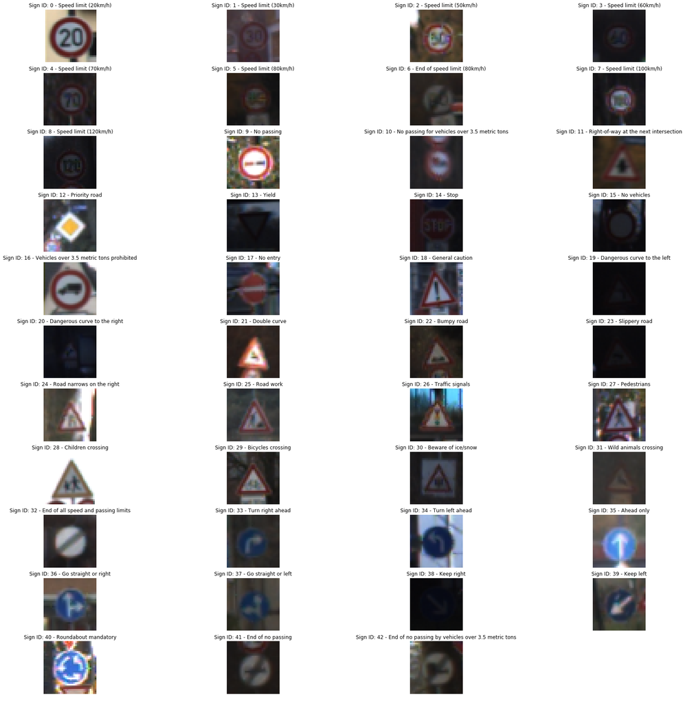

```python
import matplotlib.pyplot as plt
%matplotlib inline
import random

# count ammount of pictures of each traffic sign - training data
cnt_train_signs = np.zeros([n_classes], dtype=int)
for x in range(len(y_train)):
    cnt_train_signs[y_train[x]]+=1

# count ammount of pictures of each traffic sign - test data
cnt_test_signs = np.zeros([n_classes], dtype=int)
for x in range(len(y_test)):
    cnt_test_signs[y_train[x]]+=1

# count ammount of pictures of each traffic sign - validation data
cnt_valid_signs = np.zeros([n_classes], dtype=int)
for x in range(len(y_valid)):
    cnt_valid_signs[y_train[x]]+=1

# plotting histogram
f, (ax1, ax2, ax3) = plt.subplots(1, 3, figsize=(20,10))
ax1.set_title('Training dataset')
ax1.bar(list(range(len(cnt_train_signs))), cnt_train_signs)
ax1.set_xlabel('Sign ID')
ax1.set_ylabel('Count')
ax1.grid(True)

ax2.set_title('Test dataset')
ax2.bar(list(range(len(cnt_train_signs))), cnt_test_signs)
ax2.set_xlabel('Sign ID')
ax2.set_ylabel('Count')
ax2.grid(True)

ax3.set_title('Validation dataset')
ax3.bar(list(range(len(cnt_train_signs))), cnt_valid_signs)
ax3.set_xlabel('Sign ID')
ax3.set_ylabel('Count')
ax3.grid(True)

# plot example image of each unique class/label
figsize_default = plt.rcParams['figure.figsize']
def display_classes(features, labels, names, n_classes, gray=0):
    # Set figure size
    plt.rcParams['figure.figsize'] = (30, 30)

    # define subplots
    ncols = 4
    nrows = 11
    _, axes = plt.subplots(nrows=nrows, ncols=ncols)

    # define images to desplay and set title
    idx = 0
    for r in range(nrows):
        for c in range(ncols):
            # choose figure
            a = axes[r][c]
            a.axis('off')

            # check if max. number of classes is reached
            if(idx == n_classes):
                if(gray==0):
                    a.imshow(np.ones([30,30,3],dtype=np.uint8)*255)
                else:
                    a.imshow(np.ones([30,30,3],dtype=np.uint8)*255,cmap='gray')
                break

            # display image
            if(gray==0):
                a.imshow(features[np.where(labels == idx)[0][0]].squeeze())
            else:
                a.imshow(features[np.where(labels == idx)[0][0]].squeeze(),cmap='gray')

            # set title
            a.set_title("Sign ID: {} - {}".format(idx,names[idx][1].decode('ascii')))

            # increase class number
            idx += 1

        # check if max. number of classes is reached
        if(idx == (n_classes+1)):
            break

    plt.rcParams['figure.figsize'] = figsize_default

display_classes(X_train_raw, y_train, name_values, n_classes)
```

## Step 2: Model Architecture - Design & Testing

### Pre-process the Data Set (normalization, grayscale, etc.)

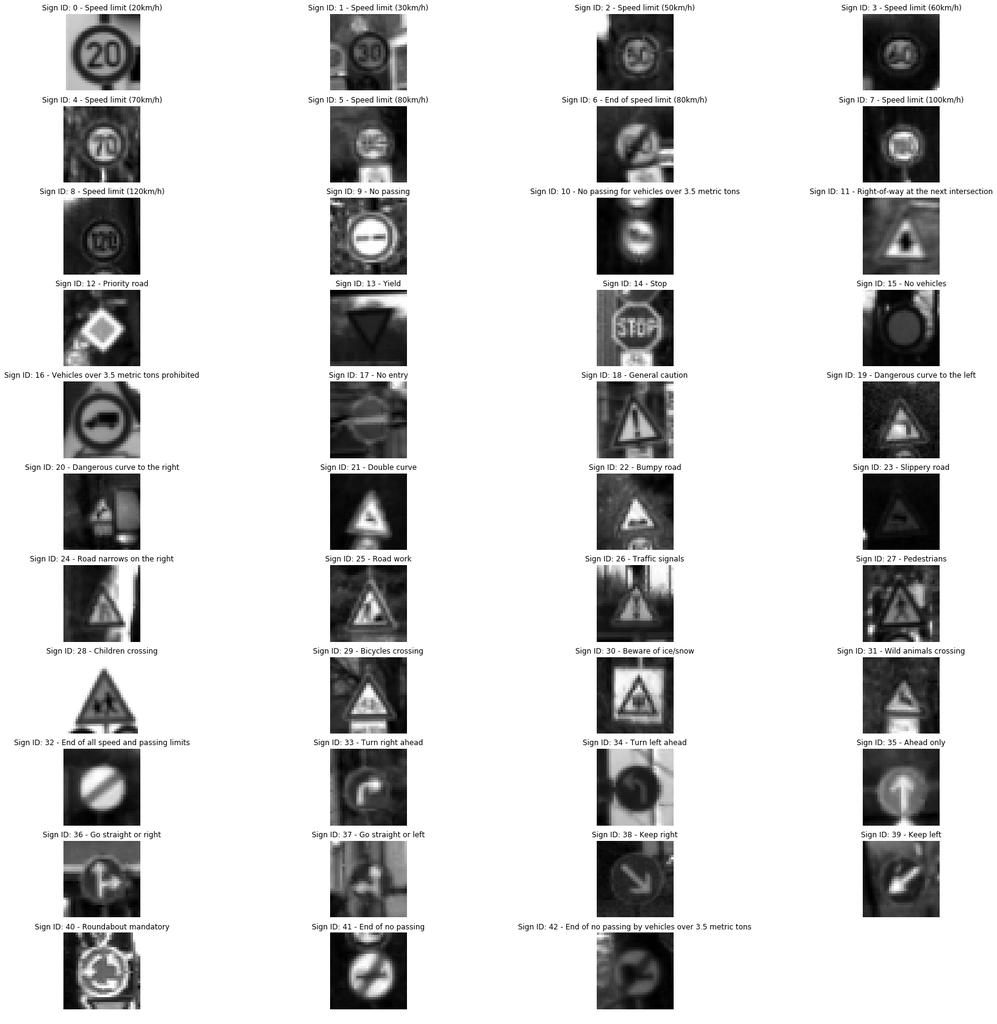

```python
from sklearn.utils import shuffle

def preprocess_data(X_data, y_data):
    # shuffle data
    #X_data, y_data = shuffle(X_data, y_data)

    # normalize data
    X_data_n = (X_data/127.5)-1

    # convert to grayscale
    #X_data_g = 0.2989 * X_data[:,:,:,0] + 0.5870 * X_data[:,:,:,1] + 0.1140 * X_data[:,:,:,2]
    X_data_g = np.sum(X_data/3, axis=3, keepdims=True)


    # convert to grayscale and normalize
    #X_data_ng =  0.2989 * X_data_n[:,:,:,0] + 0.5870 * X_data_n[:,:,:,1] + 0.1140 * X_data_n[:,:,:,2]
    X_data_ng = np.sum(X_data_n/3, axis=3, keepdims=True)

    return X_data_n, X_data_g, X_data_ng, y_data

# preprocess data
X_train_n, X_train_g, X_train_ng, y_train = preprocess_data(X_train_raw, y_train)
X_test_n, X_test_g, X_test_ng, y_test = preprocess_data(X_test_raw, y_test)
X_valid_n, X_valid_g, X_valid_ng, y_valid = preprocess_data(X_valid_raw, y_valid)

# display
display_classes(X_train_g, y_train, name_values, n_classes, 1)
```

## SOLUTION: Implement LeNet-5

Implement the [LeNet-5](http://yann.lecun.com/exdb/lenet/) neural network architecture.

This is the only cell you need to edit.

### Input

The LeNet architecture accepts a 32x32xC image as input, where C is the number of color channels. Since the used images are grayscale, C is 1 in this case.

### Architecture

**Layer 1: Convolutional.** The output shape should be 28x28x6.

**Activation.** Your choice of activation function.

**Pooling.** The output shape should be 14x14x6.

**Layer 2: Convolutional.** The output shape should be 10x10x16.

**Activation.** Your choice of activation function.

**Pooling.** The output shape should be 5x5x16.

**Flatten.** Flatten the output shape of the final pooling layer such that it's 1D instead of 3D. The easiest way to do is by using `tf.contrib.layers.flatten`, which is already imported for you.

**Layer 3: Fully Connected.** This should have 120 outputs.

**Activation.** Your choice of activation function.

**Layer 4: Fully Connected.** This should have 84 outputs.

**Activation.** Your choice of activation function.

### Output

```python
import tensorflow as tf
from tensorflow.contrib.layers import flatten

def LeNet(x):
    # Arguments used for tf.truncated_normal, randomly defines variables for the weights and biases for each layer
    mu = 0
    sigma = 0.1

    # Layer 1: Convolutional. Input = 32x32x1. Output = 28x28x6.
    conv1_W = tf.Variable(tf.truncated_normal(shape=(5, 5, 1, 6), mean = mu, stddev = sigma))
    conv1_b = tf.Variable(tf.zeros(6))
    conv1   = tf.nn.conv2d(x, conv1_W, strides=[1, 1, 1, 1], padding='VALID') + conv1_b

    # Activation.
    conv1 = tf.nn.relu(conv1)

    # Pooling. Input = 28x28x6. Output = 14x14x6.
    conv1 = tf.nn.max_pool(conv1, ksize=[1, 2, 2, 1], strides=[1, 2, 2, 1], padding='VALID')

    # Layer 2: Convolutional. Output = 10x10x16.
    conv2_W = tf.Variable(tf.truncated_normal(shape=(5, 5, 6, 16), mean = mu, stddev = sigma))
    conv2_b = tf.Variable(tf.zeros(16))
    conv2   = tf.nn.conv2d(conv1, conv2_W, strides=[1, 1, 1, 1], padding='VALID') + conv2_b

    # Activation.
    conv2 = tf.nn.relu(conv2)

    # Pooling. Input = 10x10x16. Output = 5x5x16.
    conv2 = tf.nn.max_pool(conv2, ksize=[1, 2, 2, 1], strides=[1, 2, 2, 1], padding='VALID')

    # Flatten. Input = 5x5x16. Output = 400.
    fc0   = flatten(conv2)

    # Layer 3: Fully Connected. Input = 400. Output = 120.
    fc1_W = tf.Variable(tf.truncated_normal(shape=(400, 120), mean = mu, stddev = sigma))
    fc1_b = tf.Variable(tf.zeros(120))
    fc1   = tf.matmul(fc0, fc1_W) + fc1_b
    fc1   = tf.nn.dropout(fc1, keep_prob)

    # Activation.
    fc1    = tf.nn.relu(fc1)

    # Layer 4: Fully Connected. Input = 120. Output = 84.
    fc2_W  = tf.Variable(tf.truncated_normal(shape=(120, 84), mean = mu, stddev = sigma))
    fc2_b  = tf.Variable(tf.zeros(84))
    fc2    = tf.matmul(fc1, fc2_W) + fc2_b
    fc2    = tf.nn.dropout(fc2, keep_prob)

    # Activation.
    fc2    = tf.nn.relu(fc2)

    # Layer 5: Fully Connected. Input = 84. Output = n_classes (43)
    fc3_W  = tf.Variable(tf.truncated_normal(shape=(84, n_classes), mean = mu, stddev = sigma))
    fc3_b  = tf.Variable(tf.zeros(n_classes))
    logits = tf.matmul(fc2, fc3_W) + fc3_b

    return logits
```

### Train, Validate and Test the Model

```python
# features and lables
x = tf.placeholder(tf.float32, (None, 32, 32, 1))
y = tf.placeholder(tf.int32, (None))
one_hot_y = tf.one_hot(y, n_classes)
keep_prob = tf.placeholder(tf.float32)
```

```python
# training parameters
EPOCHS = 27
BATCH_SIZE = 156
rate = 0.00097

# dropout
keep_prob_train = 0.5
keep_prob_valid = 1
```

```python
# training pipeline
logits = LeNet(x)
cross_entropy = tf.nn.softmax_cross_entropy_with_logits(labels=one_hot_y, logits=logits)
loss_operation = tf.reduce_mean(cross_entropy)
optimizer = tf.train.AdamOptimizer(learning_rate = rate)
training_operation = optimizer.minimize(loss_operation)
```

[output not shown]

```python
# evaluation pipeline
correct_prediction = tf.equal(tf.argmax(logits, 1), tf.argmax(one_hot_y, 1))
accuracy_operation = tf.reduce_mean(tf.cast(correct_prediction, tf.float32))
saver = tf.train.Saver()

def evaluate(X_data, y_data):
    num_examples = len(X_data)
    total_accuracy = 0
    sess = tf.get_default_session()
    for offset in range(0, num_examples, BATCH_SIZE):
        batch_x, batch_y = X_data[offset:offset+BATCH_SIZE], y_data[offset:offset+BATCH_SIZE]
        accuracy = sess.run(accuracy_operation, feed_dict={x: batch_x, y: batch_y, keep_prob: keep_prob_valid})
        total_accuracy += (accuracy * len(batch_x))
    return total_accuracy / num_examples
```

```python
# training set
X_train = X_train_ng
X_valid = X_valid_ng
X_test = X_test_ng
```

```python
# training the model
with tf.Session() as sess:
    sess.run(tf.global_variables_initializer())
    num_examples = len(X_train)

    print("Training...")
    print()
    for i in range(EPOCHS):
        X_train, y_train = shuffle(X_train, y_train)
        for offset in range(0, num_examples, BATCH_SIZE):
            end = offset + BATCH_SIZE
            batch_x, batch_y = X_train[offset:end], y_train[offset:end]
            sess.run(training_operation, feed_dict={x: batch_x, y: batch_y, keep_prob: keep_prob_train})

        validation_accuracy = evaluate(X_valid, y_valid)
        print("EPOCH {} ...".format(i+1))
        print("Validation Accuracy = {:.3f}".format(validation_accuracy))
        print()

    saver.save(sess, './lenet')
    print("Model saved")
```

```
Training...

EPOCH 1 ...
Validation Accuracy = 0.526

EPOCH 2 ...
Validation Accuracy = 0.751

EPOCH 3 ...
Validation Accuracy = 0.841

EPOCH 4 ...
Validation Accuracy = 0.853

EPOCH 5 ...
Validation Accuracy = 0.881

EPOCH 6 ...
Validation Accuracy = 0.896

EPOCH 7 ...
Validation Accuracy = 0.912

EPOCH 8 ...
Validation Accuracy = 0.920

EPOCH 9 ...
Validation Accuracy = 0.934

EPOCH 10 ...
Validation Accuracy = 0.935

EPOCH 11 ...
Validation Accuracy = 0.944

EPOCH 12 ...
Validation Accuracy = 0.938

EPOCH 13 ...
Validation Accuracy = 0.941
```

[output cut: 29 more lines]

```
Validation Accuracy = 0.954

EPOCH 24 ...
Validation Accuracy = 0.954

EPOCH 25 ...
Validation Accuracy = 0.955

EPOCH 26 ...
Validation Accuracy = 0.951

EPOCH 27 ...
Validation Accuracy = 0.954

Model saved
```

```python
# evaluate model
with tf.Session() as sess:
    sess.run(tf.global_variables_initializer())
    saver.restore(sess, tf.train.latest_checkpoint('.'))

    test_accuracy = evaluate(X_train, y_train)
    print("Train Accuracy = {:.3f}".format(test_accuracy))
```

[output not shown]

```
Train Accuracy = 0.995
```

```python
# evaluate model
with tf.Session() as sess:
    sess.run(tf.global_variables_initializer())
    saver.restore(sess, tf.train.latest_checkpoint('.'))

    test_accuracy = evaluate(X_test, y_test)
    print("Test Accuracy = {:.3f}".format(test_accuracy))
```

```
Test Accuracy = 0.934
```

## Step 3: Test on New Images

### Load and Output the Images

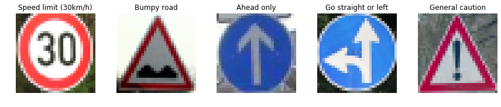

```python
import glob
import cv2

def plot_figures(figures, nrows = 1, ncols=1, labels=None):
    fig, axs = plt.subplots(ncols=ncols, nrows=nrows, figsize=(12, 14))
    axs = axs.ravel()
    for index, title in zip(range(len(figures)), figures):
        axs[index].imshow(figures[title], plt.gray())
        if(labels != None):
           axs[index].set_title(labels[index])
        else:
            axs[index].set_title(title)

        axs[index].set_axis_off()

    plt.tight_layout()

# read images
images_GER = sorted(glob.glob('./my_signs/*.png'))
labels_GER = np.array([1, 22, 35, 37, 18]) # hardcoded labels of test images according to table

# display images
figures = {}
labels = {}
signs_GER = []
index = 0
for image in images_GER:
    img = cv2.cvtColor(cv2.imread(image), cv2.COLOR_BGR2RGB)
    signs_GER.append(img)
    figures[index] = img
    labels[index] = name_values[labels_GER[index]][1].decode('ascii')
    index += 1

plot_figures(figures, 1, 5, labels)

# transform images into numpy array
signs_GER = np.array(signs_GER)
```

### Prediction for each image

```python
# preprecess images
X_test_GER_n, X_test_GER_g, X_test_GER_ng, y_test_GER = preprocess_data(signs_GER, labels_GER)

# define features for model
X_test_GER = X_test_GER_g

# evaluate model
with tf.Session() as sess:
    sess.run(tf.global_variables_initializer())
    saver.restore(sess, tf.train.latest_checkpoint('.'))

    test_GER_accuracy = evaluate(X_test_GER, y_test_GER)
    print("Test Accuracy = {:.3f}".format(test_GER_accuracy))
```

```
Test Accuracy = 1.000
```

### Performance

```python
for i in range(len(y_test_GER)):
    X_tmp = []
    y_tmp = []

    X_tmp.append(X_test_GER[i])
    X_tmp.append(X_test_GER[i])

    y_tmp.append(y_test_GER[i])
    y_tmp.append(y_test_GER[i])

    with tf.Session() as sess:
        sess.run(tf.global_variables_initializer())
        saver.restore(sess, tf.train.latest_checkpoint('.'))
        acc = evaluate(X_tmp, y_tmp)
        print('Image {}'.format(i+1))
        print("Image Accuracy = {:.3f}".format(acc))
        print()
```

```
Image 1
Image Accuracy = 1.000

Image 2
Image Accuracy = 1.000

Image 3
Image Accuracy = 1.000

Image 4
Image Accuracy = 1.000

Image 5
Image Accuracy = 1.000
```

### Top 5 Softmax Probabilities for each image

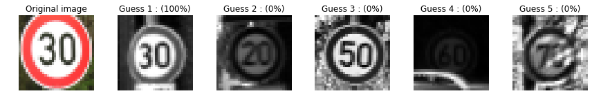

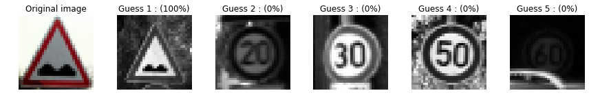

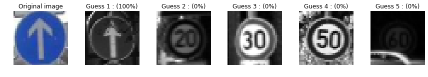

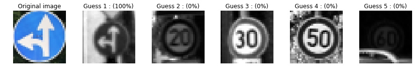

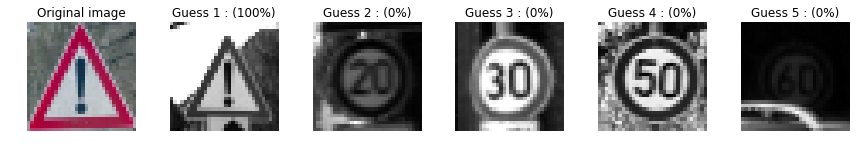

```python
k_size = 5
logits_softmax = tf.nn.softmax(logits)
top_k = tf.nn.top_k(logits_softmax, k=k_size)

with tf.Session() as sess:
    sess.run(tf.global_variables_initializer())
    saver.restore(sess, "./lenet")
    logits_softmax_GER = sess.run(logits_softmax, feed_dict={x: X_test_GER, keep_prob: 1.0})
    top_k_GER = sess.run(top_k, feed_dict={x: X_test_GER, keep_prob: 1.0})

    for i in range(5):
        figures = {}
        labels = {}

        figures[0] = signs_GER[i]
        labels[0] = "Original image"

        for j in range(k_size):
            labels[j+1] = 'Guess {} : ({:.0f}%)'.format(j+1, 100*top_k_GER[0][i][j])
            figures[j+1] = X_test[np.argwhere(y_test == top_k_GER[1][i][j])[0]].squeeze()

        plot_figures(figures, 1, 6, labels)
```